# Binary Classification Model for Edible Mushrooms Using R

David Lowe

June 15, 2018

Template Credit: Adapted from a template made available by Dr. Jason Brownlee of Machine Learning Mastery (http://machinelearningmastery.com/)

Dataset Used: Mushroom Data Set

Dataset ML Model: Binary classification with categorical attributes

Dataset Reference: https://archive.ics.uci.edu/ml/datasets/Mushroom

One potential source of performance benchmarks: https://www.kaggle.com/uciml/mushroom-classification

INTRODUCTION: This data set includes descriptions of hypothetical samples corresponding to 23 species of gilled mushrooms in the Agaricus and Lepiota Family (pp. 500-525). Each species is identified as definitely edible or definitely poisonous. The Guide, The Audubon Society Field Guide to North American Mushrooms (1981). G. H. Lincoff (Pres.), New York: Alfred A. Knopf, clearly states that there is no simple rule for determining the edibility of a mushroom.

CONCLUSION: The baseline performance of predicting the class variable achieved an average accuracy of 98.65%, which was very encouraging. Four algorithms (Logistic Regression, Random Forest, AdaBoost, and Stochastic Gradient Boosting) yielded the top accuracy result of 100% using the training dataset alone. The training dataset contained 65% of the records from the original dataset (or 5,282 records), whereas the validation dataset had the remainder 35% or 2,842 records.

After applying the validation dataset to the four top training algorithms, all four algorithms continued to perform and achieved the accuracy of 100% with the validation data. Considering the Logistic Regression models required the least amount of training time, the recommendation is to consider using the Logistic Regression model for all future mushroom predictions.

The purpose of this project is to analyze predictions using various machine learning algorithms and to document the steps using a template. Working through machine learning problems from end-to-end requires a structured modeling approach. Working problems through a project template can also encourage us to think about the problem more critically, to challenge our assumptions, and to get proficient at all parts of a modeling project.

The project aims to touch on the following areas:

1. Document a predictive modeling problem end-to-end.
2. Explore data cleaning and transformation options
3. Explore non-ensemble and ensemble algorithms for baseline model performance
4. Explore algorithm tuning techniques for improving model performance

Any predictive modeling machine learning project genrally can be broken down into about six major tasks:

1. Prepare Problem
2. Summarize Data
3. Prepare Data
4. Model and Evaluate Algorithms
5. Improve Accuracy or Results
6. Finalize Model and Present Results

## 1. Prepare Problem

### 1.a) Load libraries

```r
library(mlbench)
library(caret)
```

```r
library(corrplot)
library(ROCR)
```

### 1.b) Load dataset

```r
startTimeScript <- proc.time()
entireDataset <- read.csv("mushrooms.csv", header= TRUE)

# Use variable totCol to hold the number of columns in the dataframe
totCol <- ncol(entireDataset)

# Move and rename the class/target column to a standard label
heading <- names(entireDataset)
heading <- heading[-1]
heading <- c(heading, "class")
entireDataset <- entireDataset[,heading]
colnames(entireDataset)[colnames(entireDataset)=="class"] <- "targetVar"
```

## 2. Summarize Data

To gain a better understanding of the data that we have on-hand, we will leverage a number of descriptive statistics and data visualization techniques. The plan is to use the results to consider new questions, review assumptions, and validate hypotheses that we can investigate later with specialized models.

### 2.a) Descriptive statistics

#### 2.a.i) Peek at the data itself.

```r
head(entireDataset)
```

```
##   cap.shape cap.surface cap.color bruises odor gill.attachment
## 1         x           s         n       t    p               f
## 2         x           s         y       t    a               f
## 3         b           s         w       t    l               f
## 4         x           y         w       t    p               f
## 5         x           s         g       f    n               f
## 6         x           y         y       t    a               f
##   gill.spacing gill.size gill.color stalk.shape stalk.root
## 1            c         n          k           e          e
## 2            c         b          k           e          c
## 3            c         b          n           e          c
## 4            c         n          n           e          e
## 5            w         b          k           t          e
## 6            c         b          n           e          c
##   stalk.surface.above.ring stalk.surface.below.ring stalk.color.above.ring
```

[output cut: 20 more lines]

#### 2.a.ii) Dimensions of the dataset.

```r
dim(entireDataset)
```

```
## [1] 8124   23
```

#### 2.a.iii) Types of the attributes.

```r
sapply(entireDataset, class)
```

```
##                cap.shape              cap.surface                cap.color
##                 "factor"                 "factor"                 "factor"
##                  bruises                     odor          gill.attachment
##                 "factor"                 "factor"                 "factor"
##             gill.spacing                gill.size               gill.color
##                 "factor"                 "factor"                 "factor"
##              stalk.shape               stalk.root stalk.surface.above.ring
##                 "factor"                 "factor"                 "factor"
## stalk.surface.below.ring   stalk.color.above.ring   stalk.color.below.ring
##                 "factor"                 "factor"                 "factor"
##                veil.type               veil.color              ring.number
##                 "factor"                 "factor"                 "factor"
##                ring.type        spore.print.color               population
##                 "factor"                 "factor"                 "factor"
##                  habitat                targetVar
##                 "factor"                 "factor"
```

#### 2.a.iv) Statistical summary of all attributes.

```r
summary(entireDataset)
```

```
##  cap.shape cap.surface   cap.color    bruises       odor
##  b: 452    f:2320      n      :2284   f:4748   n      :3528
##  c:   4    g:   4      g      :1840   t:3376   f      :2160
##  f:3152    s:2556      e      :1500            s      : 576
##  k: 828    y:3244      y      :1072            y      : 576
##  s:  32                w      :1040            a      : 400
##  x:3656                b      : 168            l      : 400
##                        (Other): 220            (Other): 484
##  gill.attachment gill.spacing gill.size   gill.color   stalk.shape
##  a: 210          c:6812       b:5612    b      :1728   e:3516
##  f:7914          w:1312       n:2512    p      :1492   t:4608
##                                         w      :1202
##                                         n      :1048
##                                         g      : 752
##                                         h      : 732
##                                         (Other):1170
##  stalk.root stalk.surface.above.ring stalk.surface.below.ring
##  ?:2480     f: 552                   f: 600
##  b:3776     k:2372                   k:2304
##  c: 556     s:5176                   s:4936
##  e:1120     y:  24                   y: 284
##  r: 192
##
##
##  stalk.color.above.ring stalk.color.below.ring veil.type veil.color
##  w      :4464           w      :4384           p:8124    n:  96
##  p      :1872           p      :1872                     o:  96
##  g      : 576           g      : 576                     w:7924
##  n      : 448           n      : 512                     y:   8
##  b      : 432           b      : 432
##  o      : 192           o      : 192
##  (Other): 140           (Other): 156
##  ring.number ring.type spore.print.color population habitat  targetVar
##  n:  36      e:2776    w      :2388      a: 384     d:3148   e:4208
##  o:7488      f:  48    n      :1968      c: 340     g:2148   p:3916
##  t: 600      l:1296    k      :1872      n: 400     l: 832
##              n:  36    h      :1632      s:1248     m: 292
##              p:3968    r      :  72      v:4040     p:1144
##                        b      :  48      y:1712     u: 368
##                        (Other): 144                 w: 192
```

#### 2.a.v) Summarize the levels of the class attribute.

```r
entireDataset_x <- entireDataset[,1:(totCol-1)]
entireDataset_y <- entireDataset[,totCol]
cbind(freq=table(entireDataset_y), percentage=prop.table(table(entireDataset_y))*100)
```

```
##   freq percentage
## e 4208   51.79714
## p 3916   48.20286
```

#### 2.a.vi) Count missing values.

```r
sapply(entireDataset, function(x) sum(is.na(x)))
```

```
##                cap.shape              cap.surface                cap.color
##                        0                        0                        0
##                  bruises                     odor          gill.attachment
##                        0                        0                        0
##             gill.spacing                gill.size               gill.color
##                        0                        0                        0
##              stalk.shape               stalk.root stalk.surface.above.ring
##                        0                        0                        0
## stalk.surface.below.ring   stalk.color.above.ring   stalk.color.below.ring
##                        0                        0                        0
##                veil.type               veil.color              ring.number
##                        0                        0                        0
##                ring.type        spore.print.color               population
##                        0                        0                        0
##                  habitat                targetVar
##                        0                        0
```

### 2.b) Data visualizations

#### 2.b.i) Univariate plots to better understand each attribute.

```r
# Set up a variable for the total number of attribute columns (totAttr)
totAttr <- totCol-1
# Set up the number of row and columns for visualization display. dispRow * dispCol should be >= totAttr
dispCol <- 4
if (totAttr%%dispCol == 0) {
dispRow <- totAttr%/%dispCol
} else {
dispRow <- (totAttr%/%dispCol) + 1
}
```

```r
# Boxplots for each attribute
#par(mfrow=c(dispRow,dispCol))
#for(i in 1:totAttr) {
#   boxplot(entireDataset[,i], main=names(entireDataset)[i])
#}
```

```r
# Histograms each attribute
#par(mfrow=c(dispRow,dispCol))
#for(i in 1:totAttr) {
#   hist(entireDataset[,i], main=names(entireDataset)[i])
#}
```

```r
# Density plot for each attribute
#par(mfrow=c(dispRow,dispCol))
#for(i in 1:totAttr) {
#   plot(density(entireDataset[,i]), main=names(entireDataset)[i])
#}
```

#### 2.b.ii) Multivariate plots to better understand the relationships between attributes

```r
# Scatterplot matrix colored by class
#pairs(targetVar~., data=entireDataset, col=entireDataset$targetVar)
```

```r
# Box and whisker plots for each attribute by class
#scales <- list(x=list(relation="free"), y=list(relation="free"))
#featurePlot(x=entireDataset_x, y=entireDataset_y, plot="box", scales=scales)
```

```r
# Density plots for each attribute by class value
#featurePlot(x=entireDataset_x, y=entireDataset_y, plot="density", scales=scales)
```

```r
# Correlation plot
#correlations <- cor(entireDataset_x)
#corrplot(correlations, method="circle")
```

## 3. Prepare Data

Some dataset may require additional preparation activities that will best exposes the structure of the problem and the relationships between the input attributes and the output variable. Some data-prep tasks might include:

- Cleaning data by removing duplicates, marking missing values and even imputing missing values.
- Feature selection where redundant features may be removed.
- Data transforms where attributes are scaled or redistributed in order to best expose the structure of the problem later to learning algorithms.

### 3.a) Data Cleaning

```r
# Not applicable for this iteration of the project.

# Mark missing values
#invalid <- 0
#entireDataset$some_col[entireDataset$some_col==invalid] <- NA

# Impute missing values
#entireDataset$some_col <- with(entireDataset, impute(some_col, mean))
```

### 3.b) Feature Selection

```r
# Removing the veil.type column since it contains only one value for all rows
entireDataset$veil.type <- NULL
```

### 3.c) Data Transforms

```r
# Not applicable for this iteration of the project.
```

### 3.d) Split-out training and validation datasets

We create a training dataset (variable name “training”) and a validation dataset (variable name “validation”).

```r
seedNum <- 888
set.seed(seedNum)

# Create a list of 80% of the rows in the original dataset we can use for training
training_index <- createDataPartition(entireDataset$targetVar, p=0.65, list=FALSE)

# Use 65% of data to training and testing the models
training <- entireDataset[training_index,]

# Select the remaining 35% of the data for validation
validation <- entireDataset[-training_index,]
```

```r
proc.time()-startTimeScript
```

```
##    user  system elapsed
##   0.198   0.019   0.223
```

## 4. Model and Evaluate Algorithms

After the data-prep, we next work on finding a workable model by evaluating a subset of machine learning algorithms that are good at exploiting the structure of the training. The typical evaluation tasks include:

- Defining test options such as cross validation and the evaluation metric to use.
- Spot checking a suite of linear and nonlinear machine learning algorithms.
- Comparing the estimated accuracy of algorithms.

For this project, we will evaluate one linear, four non-linear and four ensemble algorithms:

Linear Algorithm: Logistic Regression

Non-Linear Algorithms: Decision Trees (CART), Naive Bayes, k-Nearest Neighbors, and Support Vector Machine

Ensemble Algorithms: Bagged CART, Random Forest, Adaboost, and Stochastic Gradient Boosting

The random number seed is reset before each run to ensure that the evaluation of each algorithm is performed using the same data splits. It ensures the results are directly comparable.

### 4.a) Set test options and evaluation metric

```r
# Run algorithms using 10-fold cross validation
control <- trainControl(method="repeatedcv", number=10, repeats=3)
metricTarget <- "Accuracy"
```

### 4.b) Generate models using linear algorithms

```r
# Logistic Regression (Classification)
startTimeModule <- proc.time()
set.seed(seedNum)
fit.glm <- train(targetVar~., data=training, method="glm", metric=metricTarget, trControl=control)
proc.time()-startTimeModule
```

```
##    user  system elapsed
##  27.724   0.157  28.196
```

### 4.c) Generate models using nonlinear algorithms

```r
# Decision Tree - CART (Regression/Classification)
startTimeModule <- proc.time()
set.seed(seedNum)
fit.cart <- train(targetVar~., data=training, method="rpart", metric=metricTarget, trControl=control)
proc.time()-startTimeModule
```

```
##    user  system elapsed
##   4.796   0.006   4.857
```

```r
# Naive Bayes (Classification)
startTimeModule <- proc.time()
set.seed(seedNum)
fit.nb <- train(targetVar~., data=training, method="nb", metric=metricTarget, trControl=control)
proc.time()-startTimeModule
```

```
##    user  system elapsed
## 149.172   0.056 150.855
```

```r
# k-Nearest Neighbors (Regression/Classification)
startTimeModule <- proc.time()
set.seed(seedNum)
fit.knn <- train(targetVar~., data=training, method="knn", metric=metricTarget, trControl=control)
proc.time()-startTimeModule
```

```
##    user  system elapsed
##  31.515   0.053  31.897
```

```r
# Support Vector Machine (Regression/Classification)
startTimeModule <- proc.time()
set.seed(seedNum)
fit.svm <- train(targetVar~., data=training, method="svmRadial", metric=metricTarget, trControl=control)
proc.time()-startTimeModule
```

```
##    user  system elapsed
## 127.120   0.556 129.450
```

### 4.d) Generate models using ensemble algorithms

In this section, we will explore the use and tuning of ensemble algorithms to see whether we can improve the results.

```r
# Bagged CART (Regression/Classification)
startTimeModule <- proc.time()
set.seed(seedNum)
fit.bagcart <- train(targetVar~., data=training, method="treebag", metric=metricTarget, trControl=control)
proc.time()-startTimeModule
```

```
##    user  system elapsed
##  62.466   0.744  63.971
```

```r
# Random Forest (Regression/Classification)
startTimeModule <- proc.time()
set.seed(seedNum)
fit.rf <- train(targetVar~., data=training, method="rf", metric=metricTarget, trControl=control)
proc.time()-startTimeModule
```

```
##    user  system elapsed
## 837.255   4.906 850.782
```

```r
# AdaBoost (Classification)
startTimeModule <- proc.time()
set.seed(seedNum)
fit.ada <- train(targetVar~., data=training, method="ada", metric=metricTarget, trControl=control)
proc.time()-startTimeModule
```

```
##     user   system  elapsed
## 1048.531    0.847 1061.568
```

```r
# Stochastic Gradient Boosting (Regression/Classification)
startTimeModule <- proc.time()
set.seed(seedNum)
fit.gbm <- train(targetVar~., data=training, method="gbm", metric=metricTarget, trControl=control, verbose=F)
proc.time()-startTimeModule
```

```
##    user  system elapsed
## 137.596   0.053 139.005
```

### 4.e) Compare baseline algorithms

```r
results <- resamples(list(LR=fit.glm, CART=fit.cart, NB=fit.nb, kNN=fit.knn, SVM=fit.svm, BagCART=fit.bagcart, RF=fit.rf, AdaBoost=fit.ada, GBM=fit.gbm))
summary(results)
```

```
##
## Call:
## summary.resamples(object = results)
##
## Models: LR, CART, NB, kNN, SVM, BagCART, RF, AdaBoost, GBM
## Number of resamples: 30
##
## Accuracy
##               Min.   1st Qu.    Median      Mean   3rd Qu.      Max. NA's
## LR       1.0000000 1.0000000 1.0000000 1.0000000 1.0000000 1.0000000    0
## CART     0.9297913 0.9437098 0.9584121 0.9560812 0.9677419 0.9810964    0
## NB       0.8920455 0.9146514 0.9260681 0.9232604 0.9300236 0.9470699    0
## kNN      0.9981061 1.0000000 1.0000000 0.9998737 1.0000000 1.0000000    0
## SVM      0.9981025 0.9981096 1.0000000 0.9992430 1.0000000 1.0000000    0
## BagCART  0.9981061 1.0000000 1.0000000 0.9999369 1.0000000 1.0000000    0
## RF       1.0000000 1.0000000 1.0000000 1.0000000 1.0000000 1.0000000    0
## AdaBoost 1.0000000 1.0000000 1.0000000 1.0000000 1.0000000 1.0000000    0
## GBM      1.0000000 1.0000000 1.0000000 1.0000000 1.0000000 1.0000000    0
##
## Kappa
##               Min.   1st Qu.    Median      Mean   3rd Qu.      Max. NA's
## LR       1.0000000 1.0000000 1.0000000 1.0000000 1.0000000 1.0000000    0
## CART     0.8596114 0.8875233 0.9167279 0.9121109 0.9353689 0.9621234    0
## NB       0.7824993 0.8285095 0.8514403 0.8457281 0.8592942 0.8936851    0
## kNN      0.9962061 1.0000000 1.0000000 0.9997471 1.0000000 1.0000000    0
## SVM      0.9961995 0.9962139 1.0000000 0.9984839 1.0000000 1.0000000    0
## BagCART  0.9962061 1.0000000 1.0000000 0.9998735 1.0000000 1.0000000    0
## RF       1.0000000 1.0000000 1.0000000 1.0000000 1.0000000 1.0000000    0
## AdaBoost 1.0000000 1.0000000 1.0000000 1.0000000 1.0000000 1.0000000    0
## GBM      1.0000000 1.0000000 1.0000000 1.0000000 1.0000000 1.0000000    0
```

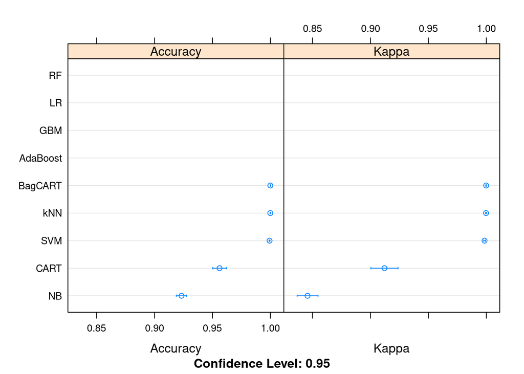

```r
dotplot(results)
```

### 6.a) Predictions on validation dataset

```r
predictions.glm <- predict(fit.glm, newdata=validation)
confusionMatrix(predictions.glm, validation$targetVar)
```

```
## Confusion Matrix and Statistics
##
##           Reference
## Prediction    e    p
##          e 1472    0
##          p    0 1370
##
##                Accuracy : 1
##                  95% CI : (0.9987, 1)
##     No Information Rate : 0.5179
##     P-Value [Acc > NIR] : < 2.2e-16
##
##                   Kappa : 1
##  Mcnemar's Test P-Value : NA
##
##             Sensitivity : 1.0000
##             Specificity : 1.0000
##          Pos Pred Value : 1.0000
##          Neg Pred Value : 1.0000
##              Prevalence : 0.5179
##          Detection Rate : 0.5179
##    Detection Prevalence : 0.5179
##       Balanced Accuracy : 1.0000
##
##        'Positive' Class : e
##
```

```r
pred.glm <- prediction(as.numeric(predictions.glm), as.numeric(validation$targetVar))
perf.glm <- performance(pred.glm, measure = "tpr", x.measure = "fpr")
plot(perf.glm, colorize=TRUE)
```

[output not shown]

```r
auc <- performance(pred.glm, measure = "auc")
auc <- auc@y.values[[1]]
auc
```

```
## [1] 1
```

### 6.a) Predictions on validation dataset

```r
predictions.rf <- predict(fit.rf, newdata=validation)
confusionMatrix(predictions.rf, validation$targetVar)
```

```
## Confusion Matrix and Statistics
##
##           Reference
## Prediction    e    p
##          e 1472    0
##          p    0 1370
##
##                Accuracy : 1
##                  95% CI : (0.9987, 1)
##     No Information Rate : 0.5179
##     P-Value [Acc > NIR] : < 2.2e-16
##
##                   Kappa : 1
##  Mcnemar's Test P-Value : NA
##
##             Sensitivity : 1.0000
##             Specificity : 1.0000
##          Pos Pred Value : 1.0000
##          Neg Pred Value : 1.0000
##              Prevalence : 0.5179
##          Detection Rate : 0.5179
##    Detection Prevalence : 0.5179
##       Balanced Accuracy : 1.0000
##
##        'Positive' Class : e
##
```

```r
pred.rf <- prediction(as.numeric(predictions.rf), as.numeric(validation$targetVar))
perf.rf <- performance(pred.rf, measure = "tpr", x.measure = "fpr")
plot(perf.rf, colorize=TRUE)
```

[output not shown]

```r
auc <- performance(pred.rf, measure = "auc")
auc <- auc@y.values[[1]]
auc
```

```
## [1] 1
```

### 6.a) Predictions on validation dataset

```r
predictions.ada <- predict(fit.ada, newdata=validation)
confusionMatrix(predictions.ada, validation$targetVar)
```

```
## Confusion Matrix and Statistics
##
##           Reference
## Prediction    e    p
##          e 1472    0
##          p    0 1370
##
##                Accuracy : 1
##                  95% CI : (0.9987, 1)
##     No Information Rate : 0.5179
##     P-Value [Acc > NIR] : < 2.2e-16
##
##                   Kappa : 1
##  Mcnemar's Test P-Value : NA
##
##             Sensitivity : 1.0000
##             Specificity : 1.0000
##          Pos Pred Value : 1.0000
##          Neg Pred Value : 1.0000
##              Prevalence : 0.5179
##          Detection Rate : 0.5179
##    Detection Prevalence : 0.5179
##       Balanced Accuracy : 1.0000
##
##        'Positive' Class : e
##
```

```r
pred.ada <- prediction(as.numeric(predictions.ada), as.numeric(validation$targetVar))
perf.ada <- performance(pred.ada, measure = "tpr", x.measure = "fpr")
plot(perf.ada, colorize=TRUE)
```

[output not shown]

```r
auc <- performance(pred.ada, measure = "auc")
auc <- auc@y.values[[1]]
auc
```

```
## [1] 1
```

### 6.a) Predictions on validation dataset

```r
predictions.gbm <- predict(fit.gbm, newdata=validation)
confusionMatrix(predictions.gbm, validation$targetVar)
```

```
## Confusion Matrix and Statistics
##
##           Reference
## Prediction    e    p
##          e 1472    0
##          p    0 1370
##
##                Accuracy : 1
##                  95% CI : (0.9987, 1)
##     No Information Rate : 0.5179
##     P-Value [Acc > NIR] : < 2.2e-16
##
##                   Kappa : 1
##  Mcnemar's Test P-Value : NA
##
##             Sensitivity : 1.0000
##             Specificity : 1.0000
##          Pos Pred Value : 1.0000
##          Neg Pred Value : 1.0000
##              Prevalence : 0.5179
##          Detection Rate : 0.5179
##    Detection Prevalence : 0.5179
##       Balanced Accuracy : 1.0000
##
##        'Positive' Class : e
##
```

```r
pred.gbm <- prediction(as.numeric(predictions.gbm), as.numeric(validation$targetVar))
perf.gbm <- performance(pred.gbm, measure = "tpr", x.measure = "fpr")
plot(perf.gbm, colorize=TRUE)
```

[output not shown]

```r
auc <- performance(pred.gbm, measure = "auc")
auc <- auc@y.values[[1]]
auc
```

```
## [1] 1
```

```r
proc.time()-startTimeScript
```

```
##     user   system  elapsed
## 2429.360    7.418 2463.848
```